# Final Project Report

Ashley Eitmontas and Ella Anderson

2025-12-07

## Introduction

Asthma remains a pressing public health concern across the United States, particularly within rural communities which often experience disproportionately high rates of the chronic disease. Asthma, a chronic inflammatory disease of the lungs, is shaped not only by biology but also by structural inequalities. In Ohio, the lifetime asthma prevalence rates are significant, affected 16.09% of adults and 9.73% of children, while current asthma affects 11.39% of adults and 6.81% of children (ODH).

In Ohio, particularly in rural and Appalachian counties, factors such as economic hardship and limited healthcare access contribute to elevated asthma prevalence. This study’s purpose is to identify which social determinants of health (SDOH) most strongly predict asthma prevalence across these counties using publicly available data indicators from DataOhio.

## Data Description

The selected predictor variables examined in this study include poverty rate, median household income, unemployment rate, educational attainment (defined as the rate of individuals 25 years or older with less than a high school degree), and uninsured rate (which measures healthcare access). The outcome variable studies was the asthma prevalence rate.

## Methods

The primary analysis approach utilized in this study was Multiple Linear Regression (MLR) implemented in R, focusing on county-level data. We had two central aims to the study. Firstly, aim one was to use MLR to measure the relationship between asthma rates and the key predictors (poverty, insurance coverage, unemployment, income, and education). The second aim was to determine which social determinants are statistically significant drivers of asthma disparities in Appalachian counties in Ohio. Model selection was guided by theory and diagnostics, including multicollinearity diagnostics. Specifically, Backward Elimination Multiple Linear Regression was employed to narrow the final set of predictors. The strength and reliability of the associations were assessed using the adjusted R<sup>2</sup>, p-values, and residual diagnostics.

## Results

#### Multiple Linear Regression Backward Elimination Findings

The full multiple linear regression model relating the selected SDOH indicators to asthma prevalence was satistically significant, with a p-value of 0.0001121. The adjusted R<sup>2</sup> value was .05305, which indicates that the predictors retained (poverty rate and median household income) explain approximately 53% if the variation in asthma prevalence across the Appalachian counties.

Sample of modeling dataset (first 10 rows)

[output not shown]

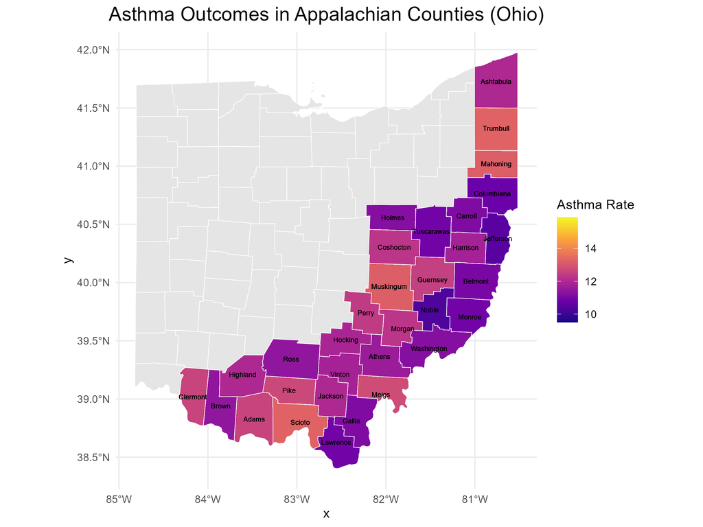

```r
knitr::include_graphics("../figs/asthma_map.png")
```

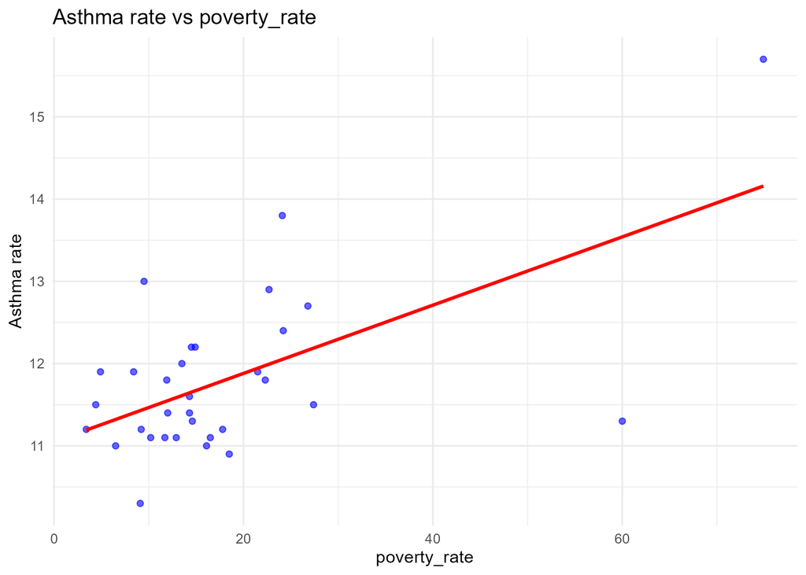

```r
knitr::include_graphics("../figs/scatter_asthma_vs_poverty_rate.png")
```

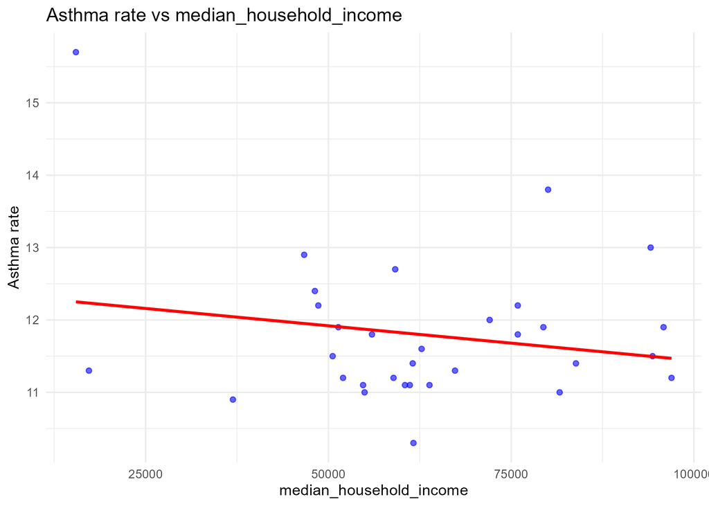

```r
knitr::include_graphics("../figs/scatter_asthma_vs_median_household_income.png")
```

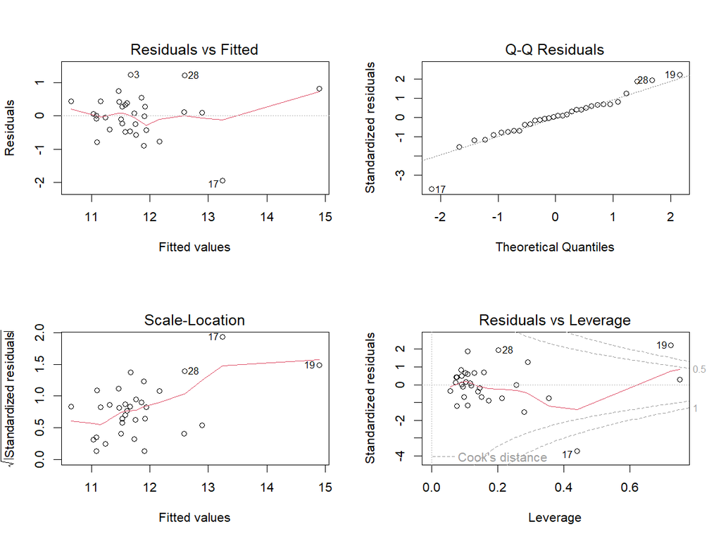

```r
knitr::include_graphics("../figs/model_diagnostics.png")
```

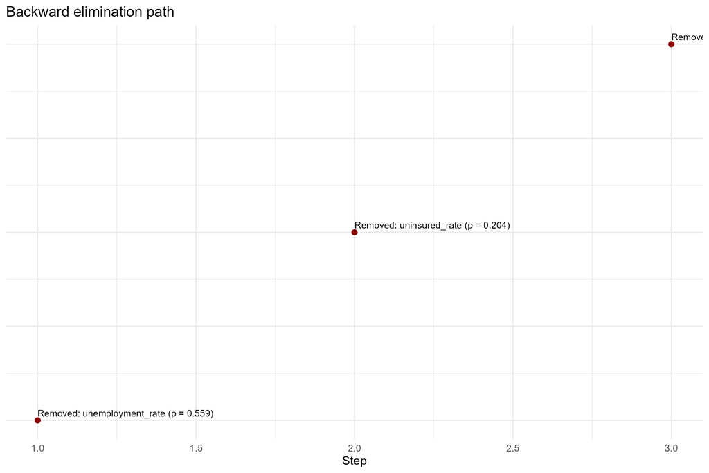

```r
knitr::include_graphics("../figs/backward_elimination_path.png")
```

#### Individual County Metrics

When linear regressions were run for each predictor on a county level, poverty and income showed the most consistent and significant results. Poverty Rate was significant in 22 out of 32 counties, and Median Household Income was significant in 20 out of 32 counties. This finding suggests that these two metrics are the strongest predictors when looking at individual regressions for each county. Additionally, the larger counties tended to have more significant results for each metric regression, likely due to a larger data set contributing to more accurate results.

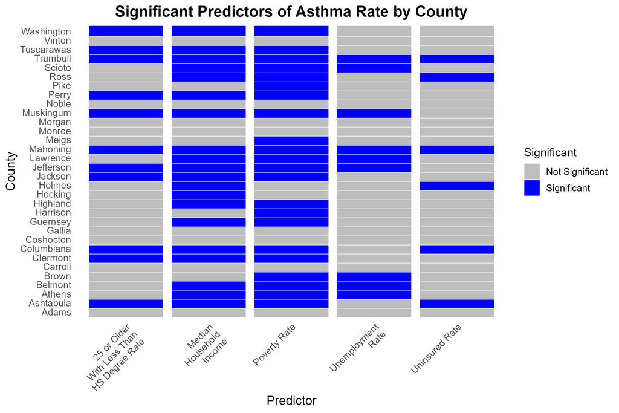

```r
knitr::include_graphics("../figs/significance_heatmap.png")
```

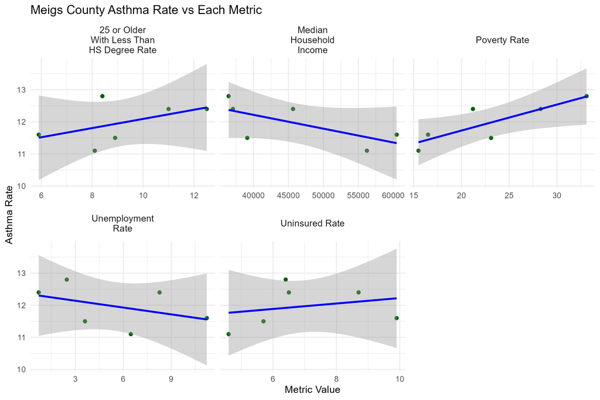

```r
knitr::include_graphics("../figs/meigs.png")
```

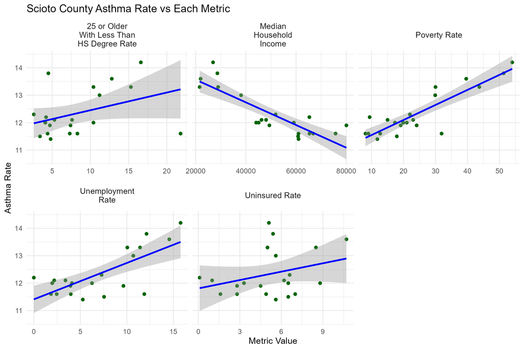

```r
knitr::include_graphics("../figs/scioto.png")
```

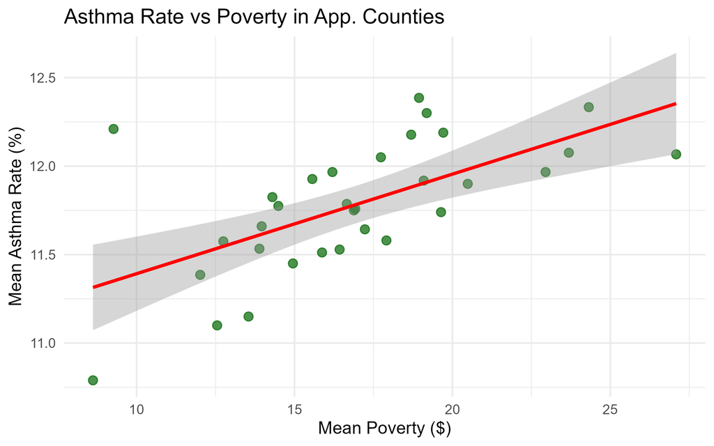

```r
knitr::include_graphics("../figs/poverty_vs_asthma_county_avg.png")
```

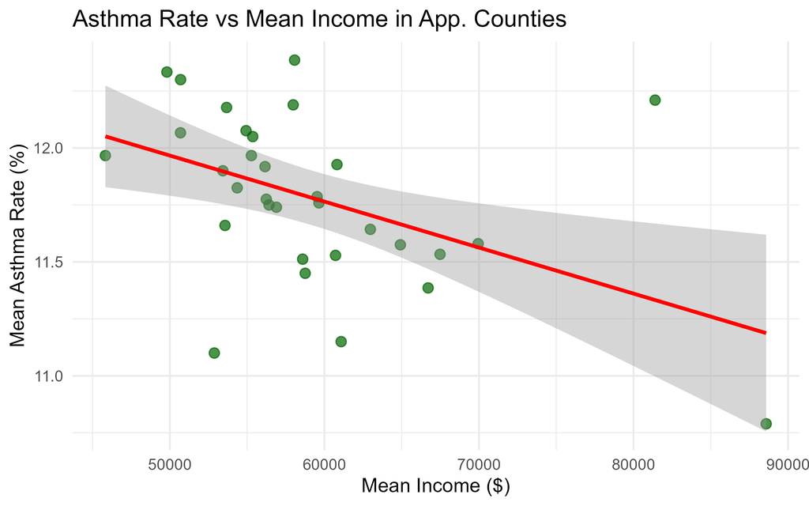

```r
knitr::include_graphics("../figs/income_vs_asthma_county_avg.png")
```

## Conclusions

Asthma outcomes in Appalachian Ohio counties are strongly shaped by structural determinants: poverty and income. These two metrics were the strongest predictors when looking at individual county regressions and were the only significant predictors retained in the final backward elimination multiple linear regression model. The findings indicate that asthma is likely related to poorer living conditions and other adverse health outcomes associated with poverty. These results produced rich implications for future research and policy. The fact that non-significant predictors included the uninsured rate and unemployment rate suggests that the broader socioeconomic context outweighs individual access measures in determining asthma prevalence at the county level in Appalachian Ohio. Therefore, tackling asthma disparities requires equity-focused strategies that move beyond healthcare access alone. Policy and public health efforts should look more upstream and focus on poverty reduction and economic development within Appalachian communities to address the root causes of inequity.

As with any study, it is also essential to include limitations within this research. The analysis is observational and cross-sectional, meaning it can only establish associations, not causality. Furthermore, the adjusted R<sup>2</sup> of 0.5305 shows that approximately 47% of the variation in asthma prevalence is unexplained by the included variables, suggesting that other unmeasured factors–such as environmental exposures (air quality, industrial sites, housing quality) and temporal dynamics–likely play a major role in asthma prevalence. The analysis is also limited to county-level data in Appalachian Ohio, which could mask important neighborhood or household-level disparities, and hinders generalization of the results to other non-Appalachian Ohio counties.

## References: